# Classification of DNA Splice Junctions

### 4.2 Implementing Naive Bayes

To evaluate the performance of the Naive Bayes model depending on the type of data in Python, two approaches are proposed.  
First, the **BernoulliNB** classifier with Laplace smoothing (`alpha = 1` in Python) is applied to binary data obtained through one-hot encoding.  
Next, **GaussianNB** is used on continuous data derived from the convolutional autoencoder, since this model assumes a normal distribution of the variables.  
This strategy allows us to compare the impact of different input transformations on the performance of the Naive Bayes classifier.

For more information on implementing the Naive Bayes model, refer to  
[BernoulliNB](https://scikit-learn.org/stable/modules/generated/sklearn.naive_bayes.MultinomialNB.html) and  
[GaussianNB](https://scikit-learn.org/stable/modules/generated/sklearn.naive_bayes.GaussianNB.html).

```python
# Entrenar BernoulliNB sin suavizado (alpha=0) con datos one-hot encoded
modelNB_alpha0 = BernoulliNB(alpha=0.0)
modelNB_alpha0.fit(X_train, y_train)

# Predecir
y_pred_NB_alpha0 = modelNB_alpha0.predict(X_test)
print("Predicciones:", y_pred_NB_alpha0)
```

# Entrenar BernoulliNB sin suavizado (alpha=0) con datos one-hot encoded modelNB_alpha0 = BernoulliNB(alpha=0.0) modelNB_alpha0.fit(X_train, y_train) # Predecir y_pred_NB_alpha0 = modelNB_alpha0.predict(X_test) print("Predicciones:", y_pred_NB_alpha0)

```
Predicciones: [0 0 0 ... 0 0 0]
```

```python
# Obtener un dataframe a partir de la matriz de confusion
report_NB_alpha0              = classification_report(y_test, y_pred_NB_alpha0, output_dict=True, target_names=['EI', 'IE', 'N'])
df_report_NB_alpha0           = pd.DataFrame(report_NB_alpha0 ).T.loc[['EI', 'IE', 'N']]
df_report_NB_alpha0 ['error'] = 1 - df_report_NB_alpha0 ['recall']
df_report_NB_alpha0 ['modelo']  = "Bernoulli B alpha=0"
df_report_NB_alpha0
```

# Obtener un dataframe a partir de la matriz de confusion report_NB_alpha0 = classification_report(y_test, y_pred_NB_alpha0, output_dict=True, target_names=['EI', 'IE', 'N']) df_report_NB_alpha0 = pd.DataFrame(report_NB_alpha0 ).T.loc[['EI', 'IE', 'N']] df_report_NB_alpha0 ['error'] = 1 - df_report_NB_alpha0 ['recall'] df_report_NB_alpha0 ['modelo'] = "Bernoulli B alpha=0" df_report_NB_alpha0

|  | precision | recall | f1-score | support | error | modelo |
| --- | --- | --- | --- | --- | --- | --- |
| EI | 0.231649 | 1.0 | 0.376161 | 243.0 | 0.0 | Bernoulli B alpha=0 |
| IE | 0.000000 | 0.0 | 0.000000 | 247.0 | 1.0 | Bernoulli B alpha=0 |
| N | 0.000000 | 0.0 | 0.000000 | 559.0 | 1.0 | Bernoulli B alpha=0 |

```python
# Entrenar BernoulliNB con suavizado (alpha=1) con datos one-hot encoded
modelNB_alpha1 = BernoulliNB(alpha=1.0)
modelNB_alpha1.fit(X_train, y_train)

# Predecir
y_pred_NB_alpha1 = modelNB_alpha0.predict(X_test)
print("Predicciones:", y_pred_NB_alpha1)
```

# Entrenar BernoulliNB con suavizado (alpha=1) con datos one-hot encoded modelNB_alpha1 = BernoulliNB(alpha=1.0) modelNB_alpha1.fit(X_train, y_train) # Predecir y_pred_NB_alpha1 = modelNB_alpha0.predict(X_test) print("Predicciones:", y_pred_NB_alpha1)

```
Predicciones: [0 0 0 ... 0 0 0]
```

```python
# Obtener un dataframe a partir de la matriz de confusion
report_NB_alpha1             = classification_report(y_test, y_pred_NB_alpha1, output_dict=True, target_names=['EI', 'IE', 'N'])
df_report_NB_alpha1          = pd.DataFrame(report_NB_alpha1).T.loc[['EI', 'IE', 'N']]
df_report_NB_alpha1['error'] = 1 - df_report_NB_alpha1['recall']
df_report_NB_alpha1['modelo']  = "BernoulliNB alpha=1"
df_report_NB_alpha1
```

# Obtener un dataframe a partir de la matriz de confusion report_NB_alpha1 = classification_report(y_test, y_pred_NB_alpha1, output_dict=True, target_names=['EI', 'IE', 'N']) df_report_NB_alpha1 = pd.DataFrame(report_NB_alpha1).T.loc[['EI', 'IE', 'N']] df_report_NB_alpha1['error'] = 1 - df_report_NB_alpha1['recall'] df_report_NB_alpha1['modelo'] = "BernoulliNB alpha=1" df_report_NB_alpha1

|  | precision | recall | f1-score | support | error | modelo |
| --- | --- | --- | --- | --- | --- | --- |
| EI | 0.231649 | 1.0 | 0.376161 | 243.0 | 0.0 | BernoulliNB alpha=1 |
| IE | 0.000000 | 0.0 | 0.000000 | 247.0 | 1.0 | BernoulliNB alpha=1 |
| N | 0.000000 | 0.0 | 0.000000 | 559.0 | 1.0 | BernoulliNB alpha=1 |

```python
# Entrenar GaussianNB con datos del autoencoder
modelNB = GaussianNB()
modelNB.fit(X_train_encoded, y_train)

# Predecir
y_pred_NB = modelNB.predict(X_test_encoded)
print("Predicciones:", y_pred_NB)
```

# Entrenar GaussianNB con datos del autoencoder modelNB = GaussianNB() modelNB.fit(X_train_encoded, y_train) # Predecir y_pred_NB = modelNB.predict(X_test_encoded) print("Predicciones:", y_pred_NB)

```
Predicciones: [1 1 2 ... 0 2 1]
```

```python
# Obtener un dataframe a partir de la matriz de confusion
report_NB             = classification_report(y_test, y_pred_NB, output_dict=True, target_names=['EI', 'IE', 'N'])
df_report_NB          = pd.DataFrame(report_NB).T.loc[['EI', 'IE', 'N']]
df_report_NB['error'] = 1 - df_report_NB['recall']
df_report_NB['modelo']  = "GaussianNB"
df_report_NB
```

# Obtener un dataframe a partir de la matriz de confusion report_NB = classification_report(y_test, y_pred_NB, output_dict=True, target_names=['EI', 'IE', 'N']) df_report_NB = pd.DataFrame(report_NB).T.loc[['EI', 'IE', 'N']] df_report_NB['error'] = 1 - df_report_NB['recall'] df_report_NB['modelo'] = "GaussianNB" df_report_NB

|  | precision | recall | f1-score | support | error | modelo |
| --- | --- | --- | --- | --- | --- | --- |
| EI | 0.942623 | 0.946502 | 0.944559 | 243.0 | 0.053498 | GaussianNB |
| IE | 0.917647 | 0.947368 | 0.932271 | 247.0 | 0.052632 | GaussianNB |
| N | 0.983636 | 0.967800 | 0.975654 | 559.0 | 0.032200 | GaussianNB |

```python
# Unir todos los resultados
df_naivebayes_final = pd.concat([df_report_NB_alpha0, df_report_NB_alpha1, df_report_NB]).reset_index().rename(columns={'index': 'clase'})
df_naivebayes_final
```

# Unir todos los resultados df_naivebayes_final = pd.concat([df_report_NB_alpha0, df_report_NB_alpha1, df_report_NB]).reset_index().rename(columns={'index': 'clase'}) df_naivebayes_final

|  | clase | precision | recall | f1-score | support | error | modelo |
| --- | --- | --- | --- | --- | --- | --- | --- |
| 0 | EI | 0.231649 | 1.000000 | 0.376161 | 243.0 | 0.000000 | Bernoulli B alpha=0 |
| 1 | IE | 0.000000 | 0.000000 | 0.000000 | 247.0 | 1.000000 | Bernoulli B alpha=0 |
| 2 | N | 0.000000 | 0.000000 | 0.000000 | 559.0 | 1.000000 | Bernoulli B alpha=0 |
| 3 | EI | 0.231649 | 1.000000 | 0.376161 | 243.0 | 0.000000 | BernoulliNB alpha=1 |
| 4 | IE | 0.000000 | 0.000000 | 0.000000 | 247.0 | 1.000000 | BernoulliNB alpha=1 |
| 5 | N | 0.000000 | 0.000000 | 0.000000 | 559.0 | 1.000000 | BernoulliNB alpha=1 |
| 6 | EI | 0.942623 | 0.946502 | 0.944559 | 243.0 | 0.053498 | GaussianNB |
| 7 | IE | 0.917647 | 0.947368 | 0.932271 | 247.0 | 0.052632 | GaussianNB |
| 8 | N | 0.983636 | 0.967800 | 0.975654 | 559.0 | 0.032200 | GaussianNB |

```python
# Graficar el f1-score por modelo y clase
pivot_f1_score = df_naivebayes_final.pivot_table(index='modelo', columns='clase', values='f1-score', aggfunc='mean')
plt.figure(figsize=(8, 4))
sns.heatmap(pivot_f1_score, annot=True, cmap='inferno', fmt=".2f")
plt.title('f1-score por Modelo y Clase')
plt.ylabel('Modelo')
plt.xlabel('Clase')
plt.tight_layout()
plt.show()
```

# Graficar el f1-score por modelo y clase pivot_f1_score = df_naivebayes_final.pivot_table(index='modelo', columns='clase', values='f1-score', aggfunc='mean') plt.figure(figsize=(8, 4)) sns.heatmap(pivot_f1_score, annot=True, cmap='inferno', fmt=".2f") plt.title('f1-score por Modelo y Clase') plt.ylabel('Modelo') plt.xlabel('Clase') plt.tight_layout() plt.show()

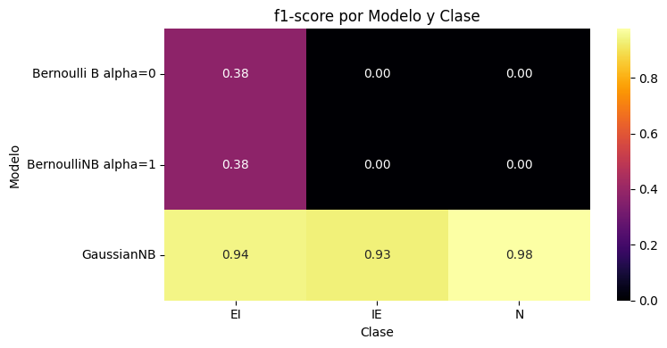

```python
# Graficar la error por modelo y clase
pivot_error = df_naivebayes_final.pivot_table(index='modelo', columns='clase', values='error', aggfunc='mean')
plt.figure(figsize=(8, 4))
sns.heatmap(pivot_error, annot=True, cmap='inferno', fmt=".2f")
plt.title('Error por Modelo y Clase')
plt.ylabel('Modelo')
plt.xlabel('Clase')
plt.tight_layout()
plt.show()
```

# Graficar la error por modelo y clase pivot_error = df_naivebayes_final.pivot_table(index='modelo', columns='clase', values='error', aggfunc='mean') plt.figure(figsize=(8, 4)) sns.heatmap(pivot_error, annot=True, cmap='inferno', fmt=".2f") plt.title('Error por Modelo y Clase') plt.ylabel('Modelo') plt.xlabel('Clase') plt.tight_layout() plt.show()

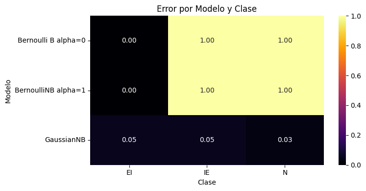

### Comment on Naive Bayes performance

As mentioned at the beginning of this section, two variants of Naive Bayes were tested: **BernoulliNB** (to evaluate Laplace smoothing) and **GaussianNB**.

The **BernoulliNB** model, which used data encoded through one-hot encoding, did not produce useful results.  
This is because the binary data derived from DNA sequences tend to be sparse and highly correlated, which makes it difficult for the model to capture relevant patterns — especially given that BernoulliNB assumes feature independence.

In contrast, the **GaussianNB** model, which was fed with data transformed by the encoder, showed very strong performance.  
It achieved high and consistent F1-scores across all three classes, as well as very low error rates.

### 4.3 Implementing Artificial Neural Network (ANN)

In this section, an artificial neural network is built with an architecture containing two hidden layers of 100 and p nodes, exploring p = 5, 10, and 20. We start the model with p = 20 and later scale the number of nodes.

```python
# Definir nodo
p = 20
```

# Definir nodo p = 20

```python
# Definir la arquitectura de la ANN
model = Sequential([
    Input(shape=(X_train_encoded.shape[1],)),
    Dense(100, activation='relu'),
    Dense(p, activation='relu'),
    Dense(3, activation='softmax') # Ya que se tienen más de 2 categorías
    ])
```

# Definir la arquitectura de la ANN model = Sequential([ Input(shape=(X_train_encoded.shape[1],)), Dense(100, activation='relu'), Dense(p, activation='relu'), Dense(3, activation='softmax') # Ya que se tienen más de 2 categorías ])

```python
# Ver detalles del modelo
model.summary()
```

# Ver detalles del modelo model.summary()

```
Model: "sequential_8"
```

```
┏━━━━━━━━━━━━━━━━━━━━━━━━━━━━━━━━━┳━━━━━━━━━━━━━━━━━━━━━━━━┳━━━━━━━━━━━━━━━┓
┃ Layer (type)                    ┃ Output Shape           ┃       Param # ┃
┡━━━━━━━━━━━━━━━━━━━━━━━━━━━━━━━━━╇━━━━━━━━━━━━━━━━━━━━━━━━╇━━━━━━━━━━━━━━━┩
│ dense_24 (Dense)                │ (None, 100)            │        48,100 │
├─────────────────────────────────┼────────────────────────┼───────────────┤
│ dense_25 (Dense)                │ (None, 20)             │         2,020 │
├─────────────────────────────────┼────────────────────────┼───────────────┤
│ dense_26 (Dense)                │ (None, 3)              │            63 │
└─────────────────────────────────┴────────────────────────┴───────────────┘
```

```
 Total params: 50,183 (196.03 KB)
```

```
 Trainable params: 50,183 (196.03 KB)
```

```
 Non-trainable params: 0 (0.00 B)
```

```python
# Compilar modelo
model.compile(optimizer='adam',
              loss='sparse_categorical_crossentropy', # Puesto que las categorías de y_train son enteras [0, 1, 2]
              metrics=['accuracy'])
```

# Compilar modelo model.compile(optimizer='adam', loss='sparse_categorical_crossentropy', # Puesto que las categorías de y_train son enteras [0, 1, 2] metrics=['accuracy'])

```python
# Definir épocas, tamaño del batch y entrenar el modelo
n_batch  = 32
n_epochs = 20

mfit = model.fit(X_train_encoded, y_train,
          epochs=n_epochs,
          batch_size=n_batch)
```

# Definir épocas, tamaño del batch y entrenar el modelo n_batch = 32 n_epochs = 20 mfit = model.fit(X_train_encoded, y_train, epochs=n_epochs, batch_size=n_batch)

```
67/67 ━━━━━━━━━━━━━━━━━━━━ 2s 4ms/step - accuracy: 0.5665 - loss: 0.9898
67/67 ━━━━━━━━━━━━━━━━━━━━ 1s 4ms/step - accuracy: 0.8900 - loss: 0.3338
67/67 ━━━━━━━━━━━━━━━━━━━━ 0s 4ms/step - accuracy: 0.9415 - loss: 0.1934
67/67 ━━━━━━━━━━━━━━━━━━━━ 1s 4ms/step - accuracy: 0.9525 - loss: 0.1493
67/67 ━━━━━━━━━━━━━━━━━━━━ 1s 3ms/step - accuracy: 0.9655 - loss: 0.1159
67/67 ━━━━━━━━━━━━━━━━━━━━ 0s 3ms/step - accuracy: 0.9739 - loss: 0.0986
67/67 ━━━━━━━━━━━━━━━━━━━━ 0s 3ms/step - accuracy: 0.9715 - loss: 0.0910
67/67 ━━━━━━━━━━━━━━━━━━━━ 0s 3ms/step - accuracy: 0.9725 - loss: 0.0824
67/67 ━━━━━━━━━━━━━━━━━━━━ 0s 3ms/step - accuracy: 0.9725 - loss: 0.0859
67/67 ━━━━━━━━━━━━━━━━━━━━ 0s 3ms/step - accuracy: 0.9717 - loss: 0.0829
67/67 ━━━━━━━━━━━━━━━━━━━━ 0s 3ms/step - accuracy: 0.9720 - loss: 0.0820
67/67 ━━━━━━━━━━━━━━━━━━━━ 0s 3ms/step - accuracy: 0.9534 - loss: 0.1180
67/67 ━━━━━━━━━━━━━━━━━━━━ 0s 3ms/step - accuracy: 0.9412 - loss: 0.1866
67/67 ━━━━━━━━━━━━━━━━━━━━ 0s 3ms/step - accuracy: 0.9617 - loss: 0.1020
67/67 ━━━━━━━━━━━━━━━━━━━━ 0s 3ms/step - accuracy: 0.9781 - loss: 0.0762
67/67 ━━━━━━━━━━━━━━━━━━━━ 0s 3ms/step - accuracy: 0.9778 - loss: 0.0704
67/67 ━━━━━━━━━━━━━━━━━━━━ 0s 3ms/step - accuracy: 0.9730 - loss: 0.0781
67/67 ━━━━━━━━━━━━━━━━━━━━ 0s 3ms/step - accuracy: 0.9680 - loss: 0.0903
67/67 ━━━━━━━━━━━━━━━━━━━━ 0s 3ms/step - accuracy: 0.9769 - loss: 0.0664
67/67 ━━━━━━━━━━━━━━━━━━━━ 0s 3ms/step - accuracy: 0.9795 - loss: 0.0596
```

```python
# Evaluar modelo
loss, acc     = model.evaluate(X_test_encoded, y_test)
y_pred        = model.predict(X_test_encoded)
y_pred_labels = y_pred.argmax(axis=1)
```

# Evaluar modelo loss, acc = model.evaluate(X_test_encoded, y_test) y_pred = model.predict(X_test_encoded) y_pred_labels = y_pred.argmax(axis=1)

```
33/33 ━━━━━━━━━━━━━━━━━━━━ 0s 3ms/step - accuracy: 0.8993 - loss: 0.2753
33/33 ━━━━━━━━━━━━━━━━━━━━ 0s 3ms/step
```

```python
# Visualizar las primeras predicciones
y_pred_labels[:100]
```

# Visualizar las primeras predicciones y_pred_labels[:100]

```
array([1, 1, 2, 2, 2, 2, 2, 1, 0, 0, 1, 0, 0, 1, 2, 0, 2, 0, 2, 0, 2, 0,
       1, 2, 2, 2, 0, 2, 2, 2, 0, 0, 1, 0, 2, 2, 2, 2, 0, 2, 2, 1, 2, 2,
       2, 2, 2, 1, 2, 2, 0, 0, 2, 1, 2, 2, 2, 2, 1, 1, 2, 0, 1, 2, 0, 2,
       2, 0, 2, 1, 2, 1, 1, 2, 1, 0, 2, 0, 1, 2, 2, 0, 2, 1, 2, 1, 1, 2,
       2, 2, 2, 2, 2, 2, 1, 2, 2, 1, 0, 1])
```

```python
# Visualizar los truth labels
y_test[:100]
```

# Visualizar los truth labels y_test[:100]

```
array([1, 1, 2, 2, 2, 1, 2, 1, 0, 1, 1, 0, 0, 1, 0, 0, 2, 0, 0, 0, 2, 0,
       1, 2, 2, 2, 1, 2, 2, 2, 0, 0, 1, 0, 2, 2, 1, 2, 0, 2, 2, 1, 2, 1,
       2, 2, 2, 1, 2, 2, 0, 0, 2, 1, 1, 2, 2, 2, 1, 1, 2, 0, 1, 2, 0, 2,
       1, 0, 2, 1, 2, 1, 1, 2, 1, 0, 1, 0, 1, 2, 2, 0, 2, 1, 2, 1, 1, 2,
       1, 2, 2, 2, 2, 2, 1, 2, 2, 1, 0, 1])
```

```python
# Obtener reporte de clasificación
report              = classification_report(y_test, y_pred_labels, output_dict=True, target_names=['EI', 'IE', 'N'])
df_report           = pd.DataFrame(report).T.loc[['EI', 'IE', 'N']]
df_report['error']  = 1 - df_report['recall']
df_report['modelo'] = 'ANN'
df_report['p']      = p
df_report
```

# Obtener reporte de clasificación report = classification_report(y_test, y_pred_labels, output_dict=True, target_names=['EI', 'IE', 'N']) df_report = pd.DataFrame(report).T.loc[['EI', 'IE', 'N']] df_report['error'] = 1 - df_report['recall'] df_report['modelo'] = 'ANN' df_report['p'] = p df_report

|  | precision | recall | f1-score | support | error | modelo | p |
| --- | --- | --- | --- | --- | --- | --- | --- |
| EI | 0.932773 | 0.913580 | 0.923077 | 243.0 | 0.086420 | ANN | 20 |
| IE | 0.982659 | 0.688259 | 0.809524 | 247.0 | 0.311741 | ANN | 20 |
| N | 0.873041 | 0.996422 | 0.930660 | 559.0 | 0.003578 | ANN | 20 |

```python
# Validar el modelo ANN con distintos valores de p = [5, 10, 20]

# Lista para guardar resultados
resultados_ann = []

for p in [5, 10, 20]:
    print(f"\nEntrenando red con p = {p} nodos en segunda capa oculta...")

    # Definir modelo
    model = Sequential([
        Input(shape=(X_train_encoded.shape[1],)),
        Dense(100, activation='relu'),
        Dense(p, activation='relu'),
        Dense(3, activation='softmax')  # 3 clases
    ])

    # Compilar
    model.compile(optimizer='adam',
                  loss='sparse_categorical_crossentropy',
                  metrics=['accuracy'])

    # Entrenar
    model.fit(X_train_encoded, y_train, epochs=20, batch_size=32)

    # Evaluar
    loss, acc = model.evaluate(X_test_encoded, y_test)
    y_pred = model.predict(X_test_encoded)
    y_pred_labels = y_pred.argmax(axis=1)

    # Reporte de clasificación
    report = classification_report(y_test, y_pred_labels, output_dict=True, target_names=['EI', 'IE', 'N'])
    df_report = pd.DataFrame(report).T.loc[['EI', 'IE', 'N']]
    df_report['error'] = 1 - df_report['recall']
    df_report['modelo'] = 'ANN' + ' p=' + str(p)
    resultados_ann.append(df_report)
```

# Validar el modelo ANN con distintos valores de p = [5, 10, 20] # Lista para guardar resultados resultados_ann = [] for p in [5, 10, 20]: print(f"\nEntrenando red con p = {p} nodos en segunda capa oculta...") # Definir modelo model = Sequential([ Input(shape=(X_train_encoded.shape[1],)), Dense(100, activation='relu'), Dense(p, activation='relu'), Dense(3, activation='softmax') # 3 clases ]) # Compilar model.compile(optimizer='adam', loss='sparse_categorical_crossentropy', metrics=['accuracy']) # Entrenar model.fit(X_train_encoded, y_train, epochs=20, batch_size=32) # Evaluar loss, acc = model.evaluate(X_test_encoded, y_test) y_pred = model.predict(X_test_encoded) y_pred_labels = y_pred.argmax(axis=1) # Reporte de clasificación report = classification_report(y_test, y_pred_labels, output_dict=True, target_names=['EI', 'IE', 'N']) df_report = pd.DataFrame(report).T.loc[['EI', 'IE', 'N']] df_report['error'] = 1 - df_report['recall'] df_report['modelo'] = 'ANN' + ' p=' + str(p) resultados_ann.append(df_report)

```
Entrenando red con p = 5 nodos en segunda capa oculta...
67/67 ━━━━━━━━━━━━━━━━━━━━ 1s 3ms/step - accuracy: 0.4817 - loss: 1.0251
67/67 ━━━━━━━━━━━━━━━━━━━━ 0s 3ms/step - accuracy: 0.7174 - loss: 0.7122
67/67 ━━━━━━━━━━━━━━━━━━━━ 0s 3ms/step - accuracy: 0.7311 - loss: 0.6508
67/67 ━━━━━━━━━━━━━━━━━━━━ 0s 3ms/step - accuracy: 0.7394 - loss: 0.6104
67/67 ━━━━━━━━━━━━━━━━━━━━ 0s 3ms/step - accuracy: 0.7355 - loss: 0.5964
67/67 ━━━━━━━━━━━━━━━━━━━━ 0s 3ms/step - accuracy: 0.7436 - loss: 0.5715
67/67 ━━━━━━━━━━━━━━━━━━━━ 0s 3ms/step - accuracy: 0.7389 - loss: 0.5576
67/67 ━━━━━━━━━━━━━━━━━━━━ 0s 3ms/step - accuracy: 0.7482 - loss: 0.5414
67/67 ━━━━━━━━━━━━━━━━━━━━ 0s 3ms/step - accuracy: 0.7461 - loss: 0.5322
67/67 ━━━━━━━━━━━━━━━━━━━━ 0s 3ms/step - accuracy: 0.7450 - loss: 0.5276
67/67 ━━━━━━━━━━━━━━━━━━━━ 0s 3ms/step - accuracy: 0.7442 - loss: 0.5433
67/67 ━━━━━━━━━━━━━━━━━━━━ 0s 3ms/step - accuracy: 0.7369 - loss: 0.5390
67/67 ━━━━━━━━━━━━━━━━━━━━ 0s 5ms/step - accuracy: 0.7341 - loss: 0.5265
67/67 ━━━━━━━━━━━━━━━━━━━━ 1s 5ms/step - accuracy: 0.7325 - loss: 0.5235
67/67 ━━━━━━━━━━━━━━━━━━━━ 1s 5ms/step - accuracy: 0.7423 - loss: 0.5057
67/67 ━━━━━━━━━━━━━━━━━━━━ 1s 5ms/step - accuracy: 0.7481 - loss: 0.4924
67/67 ━━━━━━━━━━━━━━━━━━━━ 0s 5ms/step - accuracy: 0.7528 - loss: 0.4844
67/67 ━━━━━━━━━━━━━━━━━━━━ 0s 5ms/step - accuracy: 0.7776 - loss: 0.3549
67/67 ━━━━━━━━━━━━━━━━━━━━ 0s 5ms/step - accuracy: 0.9420 - loss: 0.1865
67/67 ━━━━━━━━━━━━━━━━━━━━ 0s 3ms/step - accuracy: 0.9622 - loss: 0.1296
33/33 ━━━━━━━━━━━━━━━━━━━━ 0s 3ms/step - accuracy: 0.9115 - loss: 0.2400
33/33 ━━━━━━━━━━━━━━━━━━━━ 0s 3ms/step

Entrenando red con p = 10 nodos en segunda capa oculta...
67/67 ━━━━━━━━━━━━━━━━━━━━ 1s 3ms/step - accuracy: 0.5541 - loss: 0.9439
67/67 ━━━━━━━━━━━━━━━━━━━━ 0s 3ms/step - accuracy: 0.8711 - loss: 0.3730
67/67 ━━━━━━━━━━━━━━━━━━━━ 0s 3ms/step - accuracy: 0.9430 - loss: 0.1999
67/67 ━━━━━━━━━━━━━━━━━━━━ 0s 3ms/step - accuracy: 0.9568 - loss: 0.1497
67/67 ━━━━━━━━━━━━━━━━━━━━ 0s 3ms/step - accuracy: 0.9606 - loss: 0.1249
67/67 ━━━━━━━━━━━━━━━━━━━━ 0s 3ms/step - accuracy: 0.9654 - loss: 0.1074
67/67 ━━━━━━━━━━━━━━━━━━━━ 0s 3ms/step - accuracy: 0.9657 - loss: 0.1014
67/67 ━━━━━━━━━━━━━━━━━━━━ 0s 3ms/step - accuracy: 0.9686 - loss: 0.0942
67/67 ━━━━━━━━━━━━━━━━━━━━ 0s 3ms/step - accuracy: 0.9654 - loss: 0.0940
67/67 ━━━━━━━━━━━━━━━━━━━━ 0s 3ms/step - accuracy: 0.9663 - loss: 0.0922
67/67 ━━━━━━━━━━━━━━━━━━━━ 0s 3ms/step - accuracy: 0.9588 - loss: 0.1094
67/67 ━━━━━━━━━━━━━━━━━━━━ 0s 3ms/step - accuracy: 0.9443 - loss: 0.1466
67/67 ━━━━━━━━━━━━━━━━━━━━ 0s 3ms/step - accuracy: 0.9430 - loss: 0.1606
67/67 ━━━━━━━━━━━━━━━━━━━━ 0s 3ms/step - accuracy: 0.9715 - loss: 0.0983
67/67 ━━━━━━━━━━━━━━━━━━━━ 0s 3ms/step - accuracy: 0.9747 - loss: 0.0832
```

[output cut: 16 more lines]

```
67/67 ━━━━━━━━━━━━━━━━━━━━ 1s 5ms/step - accuracy: 0.9652 - loss: 0.1103
67/67 ━━━━━━━━━━━━━━━━━━━━ 0s 3ms/step - accuracy: 0.9578 - loss: 0.1172
67/67 ━━━━━━━━━━━━━━━━━━━━ 0s 3ms/step - accuracy: 0.9519 - loss: 0.1390
67/67 ━━━━━━━━━━━━━━━━━━━━ 0s 3ms/step - accuracy: 0.9445 - loss: 0.1590
67/67 ━━━━━━━━━━━━━━━━━━━━ 0s 3ms/step - accuracy: 0.9648 - loss: 0.1040
67/67 ━━━━━━━━━━━━━━━━━━━━ 0s 3ms/step - accuracy: 0.9733 - loss: 0.0845
67/67 ━━━━━━━━━━━━━━━━━━━━ 0s 3ms/step - accuracy: 0.9793 - loss: 0.0773
67/67 ━━━━━━━━━━━━━━━━━━━━ 0s 3ms/step - accuracy: 0.9798 - loss: 0.0695
67/67 ━━━━━━━━━━━━━━━━━━━━ 0s 3ms/step - accuracy: 0.9836 - loss: 0.0618
67/67 ━━━━━━━━━━━━━━━━━━━━ 0s 3ms/step - accuracy: 0.9857 - loss: 0.0570
67/67 ━━━━━━━━━━━━━━━━━━━━ 0s 3ms/step - accuracy: 0.9824 - loss: 0.0534
67/67 ━━━━━━━━━━━━━━━━━━━━ 0s 3ms/step - accuracy: 0.9822 - loss: 0.0551
67/67 ━━━━━━━━━━━━━━━━━━━━ 0s 3ms/step - accuracy: 0.9850 - loss: 0.0539
33/33 ━━━━━━━━━━━━━━━━━━━━ 0s 2ms/step - accuracy: 0.9065 - loss: 0.3325
33/33 ━━━━━━━━━━━━━━━━━━━━ 0s 4ms/step
```

```python
# Concatenar resultados
df_ann_final = pd.concat(resultados_ann).reset_index().rename(columns={'index': 'clase'})

# Mostrar resultados
print("Resultados por clase para cada valor de p:")
df_ann_final
```

# Concatenar resultados df_ann_final = pd.concat(resultados_ann).reset_index().rename(columns={'index': 'clase'}) # Mostrar resultados print("Resultados por clase para cada valor de p:") df_ann_final

```
Resultados por clase para cada valor de p:
```

|  | clase | precision | recall | f1-score | support | error | modelo |
| --- | --- | --- | --- | --- | --- | --- | --- |
| 0 | EI | 0.954733 | 0.954733 | 0.954733 | 243.0 | 0.045267 | ANN p=5 |
| 1 | IE | 0.877323 | 0.955466 | 0.914729 | 247.0 | 0.044534 | ANN p=5 |
| 2 | N | 0.990689 | 0.951699 | 0.970803 | 559.0 | 0.048301 | ANN p=5 |
| 3 | EI | 0.881481 | 0.979424 | 0.927875 | 243.0 | 0.020576 | ANN p=10 |
| 4 | IE | 0.906504 | 0.902834 | 0.904665 | 247.0 | 0.097166 | ANN p=10 |
| 5 | N | 0.984991 | 0.939177 | 0.961538 | 559.0 | 0.060823 | ANN p=10 |
| 6 | EI | 0.960870 | 0.909465 | 0.934461 | 243.0 | 0.090535 | ANN p=20 |
| 7 | IE | 0.925620 | 0.906883 | 0.916155 | 247.0 | 0.093117 | ANN p=20 |
| 8 | N | 0.944541 | 0.974955 | 0.959507 | 559.0 | 0.025045 | ANN p=20 |

```python
# Graficar el f1-score por modelo y clase
pivot_f1_score = df_ann_final.pivot_table(index='modelo', columns='clase', values='f1-score', aggfunc='mean')
plt.figure(figsize=(8, 4))
sns.heatmap(pivot_f1_score, annot=True, cmap='inferno', fmt=".2f")
plt.title('f1-score por Modelo y Clase')
plt.ylabel('Modelo')
plt.xlabel('Clase')
plt.tight_layout()
plt.show()
```

# Graficar el f1-score por modelo y clase pivot_f1_score = df_ann_final.pivot_table(index='modelo', columns='clase', values='f1-score', aggfunc='mean') plt.figure(figsize=(8, 4)) sns.heatmap(pivot_f1_score, annot=True, cmap='inferno', fmt=".2f") plt.title('f1-score por Modelo y Clase') plt.ylabel('Modelo') plt.xlabel('Clase') plt.tight_layout() plt.show()

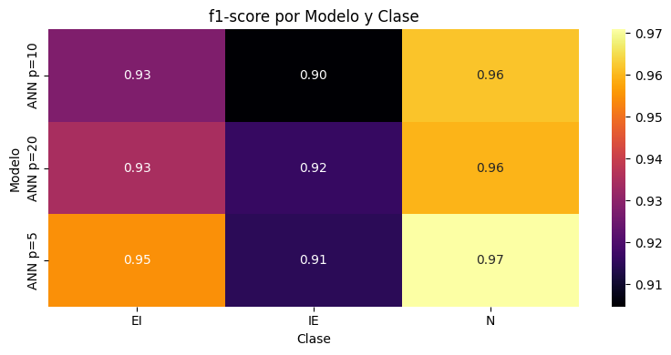

```python
# Graficar la error por modelo y clase
pivot_error = df_ann_final.pivot_table(index='modelo', columns='clase', values='error', aggfunc='mean')
plt.figure(figsize=(8, 4))
sns.heatmap(pivot_error, annot=True, cmap='inferno', fmt=".2f")
plt.title('Error por Modelo y Clase')
plt.ylabel('Modelo')
plt.xlabel('Clase')
plt.tight_layout()
plt.show()
```

# Graficar la error por modelo y clase pivot_error = df_ann_final.pivot_table(index='modelo', columns='clase', values='error', aggfunc='mean') plt.figure(figsize=(8, 4)) sns.heatmap(pivot_error, annot=True, cmap='inferno', fmt=".2f") plt.title('Error por Modelo y Clase') plt.ylabel('Modelo') plt.xlabel('Clase') plt.tight_layout() plt.show()

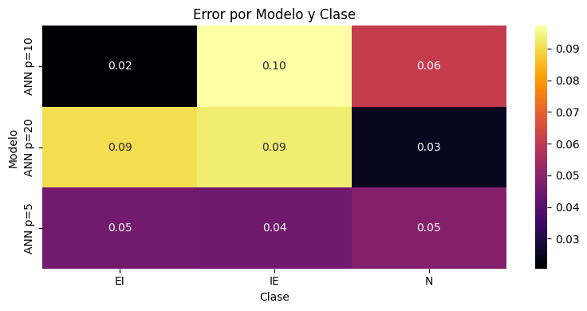

### Comment on ANN model performance

The artificial neural network (ANN) model shows solid overall performance, with high and consistent f1-scores across all classes. As the number of nodes in the 2nd hidden layer (p) increases, the f1-score remains steady, though without the clear improvements seen in the kNN model relative to k.

Regarding classes, class N performs best, with f1-scores above 0.96 and minimal errors. Class EI follows, while class IE shows an error increase when p rises from 5 to 10, suggesting possible overfitting.

### 4.4 Implement the Support Vector Machine model

In this section, a Support Vector Machine model is built with two configurations: `linear kernel` and `rbf`. We begin with the linear kernel implementation.

```python
# Crear modelo SVM
model = SVC(kernel='linear')
```

# Crear modelo SVM model = SVC(kernel='linear')

```python
# Entrenar el modelo
model.fit(X_train_encoded, y_train)
```

# Entrenar el modelo model.fit(X_train_encoded, y_train)

```
SVC(kernel='linear')
```

```python
# Hacer Predicciones
y_pred = model.predict(X_test_encoded)
```

# Hacer Predicciones y_pred = model.predict(X_test_encoded)

```python
# Crear reporte de clasificación
report = classification_report(
    y_test,
    y_pred,
    output_dict=True,
    target_names=['EI', 'IE', 'N']
    )
```

# Crear reporte de clasificación report = classification_report( y_test, y_pred, output_dict=True, target_names=['EI', 'IE', 'N'] )

```python
# Crear DataFrame con métricas por clase
df_report = pd.DataFrame(report).T.loc[['EI', 'IE', 'N']]
df_report['error'] = 1 - df_report['recall']
df_report['kernel'] = 'lineal'
df_report
```

# Crear DataFrame con métricas por clase df_report = pd.DataFrame(report).T.loc[['EI', 'IE', 'N']] df_report['error'] = 1 - df_report['recall'] df_report['kernel'] = 'lineal' df_report

|  | precision | recall | f1-score | support | error | kernel |
| --- | --- | --- | --- | --- | --- | --- |
| EI | 0.882129 | 0.954733 | 0.916996 | 243.0 | 0.045267 | lineal |
| IE | 0.905738 | 0.894737 | 0.900204 | 247.0 | 0.105263 | lineal |
| N | 0.968635 | 0.939177 | 0.953678 | 559.0 | 0.060823 | lineal |

```python
# Explorar las dos opciones de kernel lineal y rbf

# Lista para almacenar resultados
resultados_svm = []

# Definir kernels a evaluar
for kernel in ['linear', 'rbf']:
    print(f"\nEntrenando SVM con kernel = '{kernel}'...")

    # Crear modelo SVM
    model = SVC(kernel=kernel)

    # Entrenar el modelo
    model.fit(X_train_encoded, y_train)

    # Predicciones
    y_pred = model.predict(X_test_encoded)

    # Reporte de clasificación
    report = classification_report(
        y_test,
        y_pred,
        output_dict=True,
        target_names=['EI', 'IE', 'N']
    )

    # Crear DataFrame con métricas por clase
    df_report = pd.DataFrame(report).T.loc[['EI', 'IE', 'N']]
    df_report['error'] = 1 - df_report['recall']
    df_report['modelo'] = "SVM " + kernel
    resultados_svm.append(df_report)
```

# Explorar las dos opciones de kernel lineal y rbf # Lista para almacenar resultados resultados_svm = [] # Definir kernels a evaluar for kernel in ['linear', 'rbf']: print(f"\nEntrenando SVM con kernel = '{kernel}'...") # Crear modelo SVM model = SVC(kernel=kernel) # Entrenar el modelo model.fit(X_train_encoded, y_train) # Predicciones y_pred = model.predict(X_test_encoded) # Reporte de clasificación report = classification_report( y_test, y_pred, output_dict=True, target_names=['EI', 'IE', 'N'] ) # Crear DataFrame con métricas por clase df_report = pd.DataFrame(report).T.loc[['EI', 'IE', 'N']] df_report['error'] = 1 - df_report['recall'] df_report['modelo'] = "SVM " + kernel resultados_svm.append(df_report)

```
Entrenando SVM con kernel = 'linear'...

Entrenando SVM con kernel = 'rbf'...
```

```python
# Concatenar resultados
df_svm_final = pd.concat(resultados_svm).reset_index().rename(columns={'index': 'clase'})

# Mostrar tabla final
print("Resultados por clase para cada kernel:")
df_svm_final
```

# Concatenar resultados df_svm_final = pd.concat(resultados_svm).reset_index().rename(columns={'index': 'clase'}) # Mostrar tabla final print("Resultados por clase para cada kernel:") df_svm_final

```
Resultados por clase para cada kernel:
```

|  | clase | precision | recall | f1-score | support | error | modelo |
| --- | --- | --- | --- | --- | --- | --- | --- |
| 0 | EI | 0.882129 | 0.954733 | 0.916996 | 243.0 | 0.045267 | SVM linear |
| 1 | IE | 0.905738 | 0.894737 | 0.900204 | 247.0 | 0.105263 | SVM linear |
| 2 | N | 0.968635 | 0.939177 | 0.953678 | 559.0 | 0.060823 | SVM linear |
| 3 | EI | 0.947791 | 0.971193 | 0.959350 | 243.0 | 0.028807 | SVM rbf |
| 4 | IE | 0.931727 | 0.939271 | 0.935484 | 247.0 | 0.060729 | SVM rbf |
| 5 | N | 0.985481 | 0.971377 | 0.978378 | 559.0 | 0.028623 | SVM rbf |

```python
# Graficar el f1-score por modelo y clase
pivot_f1_score = df_svm_final.pivot_table(index='modelo', columns='clase', values='f1-score', aggfunc='mean')
plt.figure(figsize=(8, 4))
sns.heatmap(pivot_f1_score, annot=True, cmap='inferno', fmt=".2f")
plt.title('f1-score por Modelo y Clase')
plt.ylabel('Modelo')
plt.xlabel('Clase')
plt.tight_layout()
plt.show()
```

# Graficar el f1-score por modelo y clase pivot_f1_score = df_svm_final.pivot_table(index='modelo', columns='clase', values='f1-score', aggfunc='mean') plt.figure(figsize=(8, 4)) sns.heatmap(pivot_f1_score, annot=True, cmap='inferno', fmt=".2f") plt.title('f1-score por Modelo y Clase') plt.ylabel('Modelo') plt.xlabel('Clase') plt.tight_layout() plt.show()

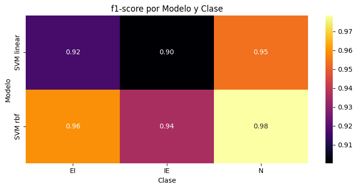

```python
# Graficar la error por modelo y clase
pivot_error = df_svm_final.pivot_table(index='modelo', columns='clase', values='error', aggfunc='mean')
plt.figure(figsize=(8, 4))
sns.heatmap(pivot_error, annot=True, cmap='inferno', fmt=".2f")
plt.title('Error por Modelo y Clase')
plt.ylabel('Modelo')
plt.xlabel('Clase')
plt.tight_layout()
plt.show()
```

# Graficar la error por modelo y clase pivot_error = df_svm_final.pivot_table(index='modelo', columns='clase', values='error', aggfunc='mean') plt.figure(figsize=(8, 4)) sns.heatmap(pivot_error, annot=True, cmap='inferno', fmt=".2f") plt.title('Error por Modelo y Clase') plt.ylabel('Modelo') plt.xlabel('Clase') plt.tight_layout() plt.show()

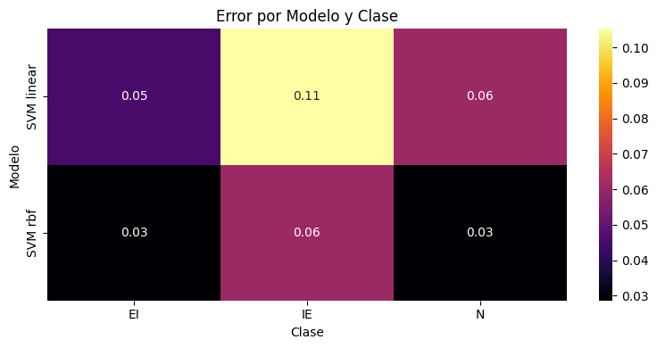

### Comment on SVM (Linear and RBF) performance

The SVM model with linear kernel provides acceptable performance, with f1-scores above 0.90 across all classes. Class N performs best, while class IE has the most error.

In summary, the SVM model with RBF kernel outperforms the linear kernel in all relevant metrics, showing better generalization.

### 4.5 Implement the Decision Tree model

In this section, a decision tree model is built with two configurations: `boosting` and `no boosting`.

```python
# Definir la función evaluar_model_arbol()

def evaluar_modelo_arbol(boosting=False, max_depth=None):
    # Seleccionar modelo
    if boosting:
        model = GradientBoostingClassifier(n_estimators=100, learning_rate=0.1, max_depth=max_depth, random_state=42)
        nombre_modelo = 'Árbol con Boosting'
    else:
        model = DecisionTreeClassifier(max_depth=max_depth, random_state=42)
        nombre_modelo = 'Árbol de Decisión'

    # Entrenar
    model.fit(X_train_encoded, y_train)

    # Predecir
    y_pred = model.predict(X_test_encoded)

    # Reporte de clasificación
    report = classification_report(
        y_test, y_pred,
        output_dict=True,
        target_names=['EI', 'IE', 'N']
    )

    # Formatear DataFrame
    df_report               = pd.DataFrame(report).T.loc[['EI', 'IE', 'N']]
    df_report['error']      = 1 - df_report['recall']
    df_report['modelo']     = nombre_modelo + ' depth=' + str(max_depth)

    return df_report
```

# Definir la función evaluar_model_arbol() def evaluar_modelo_arbol(boosting=False, max_depth=None): # Seleccionar modelo if boosting: model = GradientBoostingClassifier(n_estimators=100, learning_rate=0.1, max_depth=max_depth, random_state=42) nombre_modelo = 'Árbol con Boosting' else: model = DecisionTreeClassifier(max_depth=max_depth, random_state=42) nombre_modelo = 'Árbol de Decisión' # Entrenar model.fit(X_train_encoded, y_train) # Predecir y_pred = model.predict(X_test_encoded) # Reporte de clasificación report = classification_report( y_test, y_pred, output_dict=True, target_names=['EI', 'IE', 'N'] ) # Formatear DataFrame df_report = pd.DataFrame(report).T.loc[['EI', 'IE', 'N']] df_report['error'] = 1 - df_report['recall'] df_report['modelo'] = nombre_modelo + ' depth=' + str(max_depth) return df_report

```python
# Evaluar ambos modelos
df_arbol = evaluar_modelo_arbol(boosting=False, max_depth=5)
df_boost = evaluar_modelo_arbol(boosting=True, max_depth=5)

# Combinar resultados
df_arboles_final = pd.concat([df_arbol, df_boost]).reset_index().rename(columns={'index': 'clase'})

# Mostrar
df_arboles_final
```

# Evaluar ambos modelos df_arbol = evaluar_modelo_arbol(boosting=False, max_depth=5) df_boost = evaluar_modelo_arbol(boosting=True, max_depth=5) # Combinar resultados df_arboles_final = pd.concat([df_arbol, df_boost]).reset_index().rename(columns={'index': 'clase'}) # Mostrar df_arboles_final

|  | clase | precision | recall | f1-score | support | error | modelo |
| --- | --- | --- | --- | --- | --- | --- | --- |
| 0 | EI | 0.893130 | 0.962963 | 0.926733 | 243.0 | 0.037037 | Árbol de Decisión depth=5 |
| 1 | IE | 0.946429 | 0.858300 | 0.900212 | 247.0 | 0.141700 | Árbol de Decisión depth=5 |
| 2 | N | 0.959147 | 0.966011 | 0.962567 | 559.0 | 0.033989 | Árbol de Decisión depth=5 |
| 3 | EI | 0.932540 | 0.967078 | 0.949495 | 243.0 | 0.032922 | Árbol con Boosting depth=5 |
| 4 | IE | 0.942857 | 0.935223 | 0.939024 | 247.0 | 0.064777 | Árbol con Boosting depth=5 |
| 5 | N | 0.983696 | 0.971377 | 0.977498 | 559.0 | 0.028623 | Árbol con Boosting depth=5 |

```python
# Graficar el f1-score por modelo y clase
pivot_f1_score = df_arboles_final.pivot_table(index='modelo', columns='clase', values='f1-score', aggfunc='mean')
plt.figure(figsize=(8, 4))
sns.heatmap(pivot_f1_score, annot=True, cmap='inferno', fmt=".2f")
plt.title('f1-score por Modelo y Clase')
plt.ylabel('Modelo')
plt.xlabel('Clase')
plt.tight_layout()
plt.show()
```

# Graficar el f1-score por modelo y clase pivot_f1_score = df_arboles_final.pivot_table(index='modelo', columns='clase', values='f1-score', aggfunc='mean') plt.figure(figsize=(8, 4)) sns.heatmap(pivot_f1_score, annot=True, cmap='inferno', fmt=".2f") plt.title('f1-score por Modelo y Clase') plt.ylabel('Modelo') plt.xlabel('Clase') plt.tight_layout() plt.show()

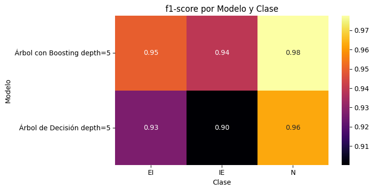

```python
# Graficar la error por modelo y clase
pivot_error = df_arboles_final.pivot_table(index='modelo', columns='clase', values='error', aggfunc='mean')
plt.figure(figsize=(8, 4))
sns.heatmap(pivot_error, annot=True, cmap='inferno', fmt=".2f")
plt.title('Error por Modelo y Clase')
plt.ylabel('Modelo')
plt.xlabel('Clase')
plt.tight_layout()
plt.show()
```

# Graficar la error por modelo y clase pivot_error = df_arboles_final.pivot_table(index='modelo', columns='clase', values='error', aggfunc='mean') plt.figure(figsize=(8, 4)) sns.heatmap(pivot_error, annot=True, cmap='inferno', fmt=".2f") plt.title('Error por Modelo y Clase') plt.ylabel('Modelo') plt.xlabel('Clase') plt.tight_layout() plt.show()

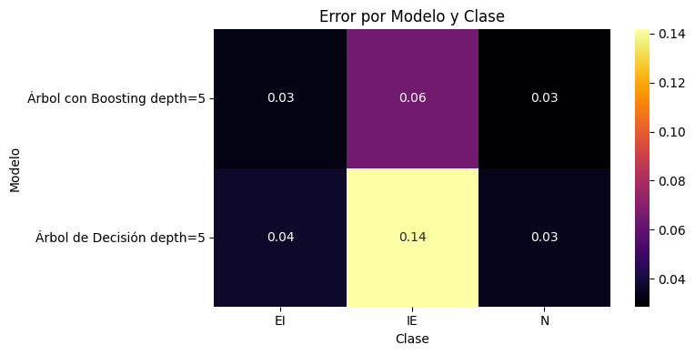

### Comment on Decision Tree model

The decision tree model with depth 5 shows solid performance, with f1-scores above 0.90 for all classes and low errors. Class N stands out, maintaining an f1-score of 0.96, while EI and IE are stable, though IE has a higher error.

Applying Boosting improves all metrics. F1-score increases slightly across all classes, reaching values above 0.94. Errors also decrease, especially for class IE.

In summary, the Boosted Tree offers higher and more consistent performance. Combining Boosting with shallow trees seems to better capture the problem structure without overfitting.

### 4.6 Implement the Random Forest model with n = 50 and 100

In this section, a Random Forest model is built with two numbers of trees: `n=50` and `n=100`.

```python
# Definir la función evaluar_random_forest()
def evaluar_random_forest(n_estimators):
    # Inicializar modelo
    model = RandomForestClassifier(n_estimators=n_estimators, random_state=42)

    # Entrenar
    model.fit(X_train_encoded, y_train)

    # Predecir
    y_pred = model.predict(X_test_encoded)

    # Obtener reporte por clase
    report = classification_report(
        y_test,
        y_pred,
        output_dict=True,
        target_names=['EI', 'IE', 'N']
    )

    # Formatear resultado en DataFrame
    df_report = pd.DataFrame(report).T.loc[['EI', 'IE', 'N']]
    df_report['error'] = 1 - df_report['recall']
    df_report['modelo'] = 'Random Forest' + ' n=' + str(n_estimators)

    return df_report
```

# Definir la función evaluar_random_forest() def evaluar_random_forest(n_estimators): # Inicializar modelo model = RandomForestClassifier(n_estimators=n_estimators, random_state=42) # Entrenar model.fit(X_train_encoded, y_train) # Predecir y_pred = model.predict(X_test_encoded) # Obtener reporte por clase report = classification_report( y_test, y_pred, output_dict=True, target_names=['EI', 'IE', 'N'] ) # Formatear resultado en DataFrame df_report = pd.DataFrame(report).T.loc[['EI', 'IE', 'N']] df_report['error'] = 1 - df_report['recall'] df_report['modelo'] = 'Random Forest' + ' n=' + str(n_estimators) return df_report

```python
# Evaluar Random Forest con 50 y 100 árboles
df_rf_50  = evaluar_random_forest(n_estimators=50)
df_rf_100 = evaluar_random_forest(n_estimators=100)

# Combinar resultados
df_rf_total = pd.concat([df_rf_50, df_rf_100]).reset_index().rename(columns={'index': 'clase'})

# Mostrar resultados
df_rf_total
```

# Evaluar Random Forest con 50 y 100 árboles df_rf_50 = evaluar_random_forest(n_estimators=50) df_rf_100 = evaluar_random_forest(n_estimators=100) # Combinar resultados df_rf_total = pd.concat([df_rf_50, df_rf_100]).reset_index().rename(columns={'index': 'clase'}) # Mostrar resultados df_rf_total

|  | clase | precision | recall | f1-score | support | error | modelo |
| --- | --- | --- | --- | --- | --- | --- | --- |
| 0 | EI | 0.925197 | 0.967078 | 0.945674 | 243.0 | 0.032922 | Random Forest n=50 |
| 1 | IE | 0.941909 | 0.919028 | 0.930328 | 247.0 | 0.080972 | Random Forest n=50 |
| 2 | N | 0.983755 | 0.974955 | 0.979335 | 559.0 | 0.025045 | Random Forest n=50 |
| 3 | EI | 0.928854 | 0.967078 | 0.947581 | 243.0 | 0.032922 | Random Forest n=100 |
| 4 | IE | 0.937759 | 0.914980 | 0.926230 | 247.0 | 0.085020 | Random Forest n=100 |
| 5 | N | 0.980180 | 0.973166 | 0.976661 | 559.0 | 0.026834 | Random Forest n=100 |

```python
# Graficar el f1-score por modelo y clase
pivot_f1_score = df_rf_total.pivot_table(index='modelo', columns='clase', values='f1-score', aggfunc='mean')
plt.figure(figsize=(8, 4))
sns.heatmap(pivot_f1_score, annot=True, cmap='inferno', fmt=".2f")
plt.title('f1-score por Modelo y Clase')
plt.ylabel('Modelo')
plt.xlabel('Clase')
plt.tight_layout()
plt.show()
```

# Graficar el f1-score por modelo y clase pivot_f1_score = df_rf_total.pivot_table(index='modelo', columns='clase', values='f1-score', aggfunc='mean') plt.figure(figsize=(8, 4)) sns.heatmap(pivot_f1_score, annot=True, cmap='inferno', fmt=".2f") plt.title('f1-score por Modelo y Clase') plt.ylabel('Modelo') plt.xlabel('Clase') plt.tight_layout() plt.show()

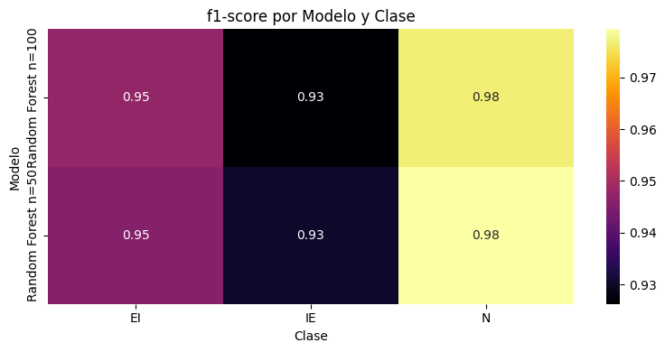

```python
# Graficar la error por modelo y clase
pivot_error = df_rf_total.pivot_table(index='modelo', columns='clase', values='error', aggfunc='mean')
plt.figure(figsize=(8, 4))
sns.heatmap(pivot_error, annot=True, cmap='inferno', fmt=".2f")
plt.title('Error por Modelo y Clase')
plt.ylabel('Modelo')
plt.xlabel('Clase')
plt.tight_layout()
plt.show()
```

# Graficar la error por modelo y clase pivot_error = df_rf_total.pivot_table(index='modelo', columns='clase', values='error', aggfunc='mean') plt.figure(figsize=(8, 4)) sns.heatmap(pivot_error, annot=True, cmap='inferno', fmt=".2f") plt.title('Error por Modelo y Clase') plt.ylabel('Modelo') plt.xlabel('Clase') plt.tight_layout() plt.show()

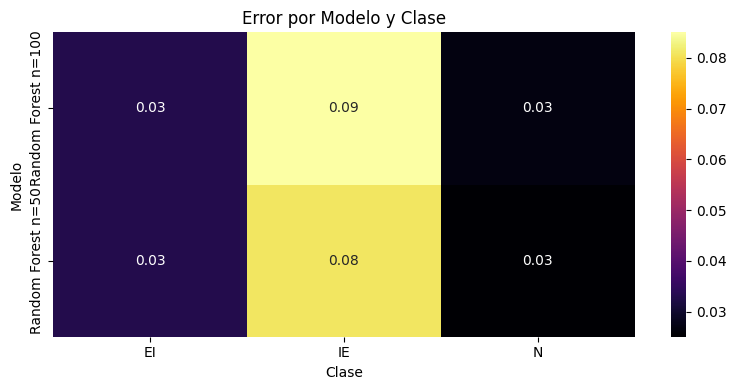

### Comment on Random Forest model

The Random Forest model with 50 trees shows very competitive performance. F1-scores exceed 0.93 across all classes, particularly class N. Errors are low and fairly balanced, except for class IE, indicating good generalization.

Increasing the number of trees to 100 does not show improvements. F1-scores remain the same, and errors remain low. This suggests that increasing the number of trees could help stabilize and fine-tune predictions, although current performance appears sufficient.

## 5 Comparison of proposed models' performance

```python
# Crear tabla comparativa de todos los modelos implementados
# Combinar resultados
df_resultado_modelos = pd.concat([df_knn_final, df_naivebayes_final, df_ann_final, df_svm_final, df_arboles_final, df_rf_total]).reset_index(drop=True)

# Mostrar resultados
df_resultado_modelos
```

# Crear tabla comparativa de todos los modelos implementados # Combinar resultados df_resultado_modelos = pd.concat([df_knn_final, df_naivebayes_final, df_ann_final, df_svm_final, df_arboles_final, df_rf_total]).reset_index(drop=True) # Mostrar resultados df_resultado_modelos

|  | clase | precision | recall | f1-score | support | error | modelo |
| --- | --- | --- | --- | --- | --- | --- | --- |
| 0 | EI | 0.633929 | 0.876543 | 0.735751 | 243.0 | 0.123457 | kNN k=1 |
| 1 | IE | 0.662420 | 0.842105 | 0.741533 | 247.0 | 0.157895 | kNN k=1 |
| 2 | N | 0.919799 | 0.656530 | 0.766180 | 559.0 | 0.343470 | kNN k=1 |
| 3 | EI | 0.630986 | 0.921811 | 0.749164 | 243.0 | 0.078189 | kNN k=3 |
| 4 | IE | 0.763699 | 0.902834 | 0.827458 | 247.0 | 0.097166 | kNN k=3 |
| 5 | N | 0.965174 | 0.694097 | 0.807492 | 559.0 | 0.305903 | kNN k=3 |
| 6 | EI | 0.665698 | 0.942387 | 0.780239 | 243.0 | 0.057613 | kNN k=5 |
| 7 | IE | 0.719136 | 0.943320 | 0.816112 | 247.0 | 0.056680 | kNN k=5 |
| 8 | N | 0.989501 | 0.674419 | 0.802128 | 559.0 | 0.325581 | kNN k=5 |
| 9 | EI | 0.728707 | 0.950617 | 0.825000 | 243.0 | 0.049383 | kNN k=7 |
| 10 | IE | 0.750000 | 0.959514 | 0.841918 | 247.0 | 0.040486 | kNN k=7 |
| 11 | N | 0.990385 | 0.737030 | 0.845128 | 559.0 | 0.262970 | kNN k=7 |
| 12 | EI | 0.231649 | 1.000000 | 0.376161 | 243.0 | 0.000000 | Bernoulli B alpha=0 |
| 13 | IE | 0.000000 | 0.000000 | 0.000000 | 247.0 | 1.000000 | Bernoulli B alpha=0 |
| 14 | N | 0.000000 | 0.000000 | 0.000000 | 559.0 | 1.000000 | Bernoulli B alpha=0 |
| 15 | EI | 0.231649 | 1.000000 | 0.376161 | 243.0 | 0.000000 | BernoulliNB alpha=1 |
| 16 | IE | 0.000000 | 0.000000 | 0.000000 | 247.0 | 1.000000 | BernoulliNB alpha=1 |
| 17 | N | 0.000000 | 0.000000 | 0.000000 | 559.0 | 1.000000 | BernoulliNB alpha=1 |
| 18 | EI | 0.958506 | 0.950617 | 0.954545 | 243.0 | 0.049383 | GaussianNB |
| 19 | IE | 0.905882 | 0.935223 | 0.920319 | 247.0 | 0.064777 | GaussianNB |
| 20 | N | 0.978300 | 0.967800 | 0.973022 | 559.0 | 0.032200 | GaussianNB |
| 21 | EI | 0.954733 | 0.954733 | 0.954733 | 243.0 | 0.045267 | ANN p=5 |
| 22 | IE | 0.877323 | 0.955466 | 0.914729 | 247.0 | 0.044534 | ANN p=5 |
| 23 | N | 0.990689 | 0.951699 | 0.970803 | 559.0 | 0.048301 | ANN p=5 |
| 24 | EI | 0.881481 | 0.979424 | 0.927875 | 243.0 | 0.020576 | ANN p=10 |
| 25 | IE | 0.906504 | 0.902834 | 0.904665 | 247.0 | 0.097166 | ANN p=10 |
| 26 | N | 0.984991 | 0.939177 | 0.961538 | 559.0 | 0.060823 | ANN p=10 |
| 27 | EI | 0.960870 | 0.909465 | 0.934461 | 243.0 | 0.090535 | ANN p=20 |
| 28 | IE | 0.925620 | 0.906883 | 0.916155 | 247.0 | 0.093117 | ANN p=20 |
| 29 | N | 0.944541 | 0.974955 | 0.959507 | 559.0 | 0.025045 | ANN p=20 |
| 30 | EI | 0.882129 | 0.954733 | 0.916996 | 243.0 | 0.045267 | SVM linear |
| 31 | IE | 0.905738 | 0.894737 | 0.900204 | 247.0 | 0.105263 | SVM linear |
| 32 | N | 0.968635 | 0.939177 | 0.953678 | 559.0 | 0.060823 | SVM linear |
| 33 | EI | 0.947791 | 0.971193 | 0.959350 | 243.0 | 0.028807 | SVM rbf |
| 34 | IE | 0.931727 | 0.939271 | 0.935484 | 247.0 | 0.060729 | SVM rbf |
| 35 | N | 0.985481 | 0.971377 | 0.978378 | 559.0 | 0.028623 | SVM rbf |
| 36 | EI | 0.893130 | 0.962963 | 0.926733 | 243.0 | 0.037037 | Árbol de Decisión depth=5 |
| 37 | IE | 0.946429 | 0.858300 | 0.900212 | 247.0 | 0.141700 | Árbol de Decisión depth=5 |
| 38 | N | 0.959147 | 0.966011 | 0.962567 | 559.0 | 0.033989 | Árbol de Decisión depth=5 |
| 39 | EI | 0.932540 | 0.967078 | 0.949495 | 243.0 | 0.032922 | Árbol con Boosting depth=5 |
| 40 | IE | 0.942857 | 0.935223 | 0.939024 | 247.0 | 0.064777 | Árbol con Boosting depth=5 |
| 41 | N | 0.983696 | 0.971377 | 0.977498 | 559.0 | 0.028623 | Árbol con Boosting depth=5 |
| 42 | EI | 0.925197 | 0.967078 | 0.945674 | 243.0 | 0.032922 | Random Forest n=50 |
| 43 | IE | 0.941909 | 0.919028 | 0.930328 | 247.0 | 0.080972 | Random Forest n=50 |
| 44 | N | 0.983755 | 0.974955 | 0.979335 | 559.0 | 0.025045 | Random Forest n=50 |
| 45 | EI | 0.928854 | 0.967078 | 0.947581 | 243.0 | 0.032922 | Random Forest n=100 |
| 46 | IE | 0.937759 | 0.914980 | 0.926230 | 247.0 | 0.085020 | Random Forest n=100 |
| 47 | N | 0.980180 | 0.973166 | 0.976661 | 559.0 | 0.026834 | Random Forest n=100 |

```python
# Graficar el f1-score por modelo y clase
pivot_f1_score = df_resultado_modelos.pivot_table(index='modelo', columns='clase', values='f1-score', aggfunc='mean')
plt.figure(figsize=(8, 4))
sns.heatmap(pivot_f1_score, annot=True, cmap='inferno', fmt=".2f")
plt.title('f1-score por Modelo y Clase')
plt.ylabel('Modelo')
plt.xlabel('Clase')
plt.tight_layout()
plt.show()
```

# Graficar el f1-score por modelo y clase pivot_f1_score = df_resultado_modelos.pivot_table(index='modelo', columns='clase', values='f1-score', aggfunc='mean') plt.figure(figsize=(8, 4)) sns.heatmap(pivot_f1_score, annot=True, cmap='inferno', fmt=".2f") plt.title('f1-score por Modelo y Clase') plt.ylabel('Modelo') plt.xlabel('Clase') plt.tight_layout() plt.show()

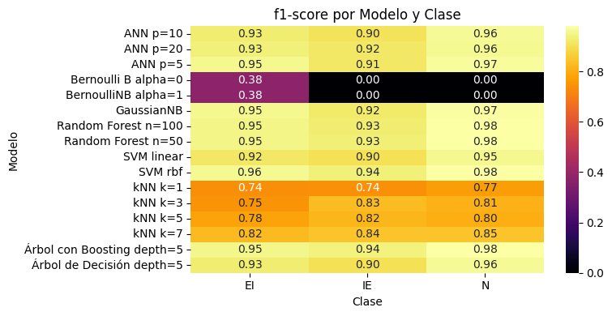

```python
# Graficar el error por modelo y clase
pivot_error = df_resultado_modelos.pivot_table(index='modelo', columns='clase', values='error', aggfunc='mean')
plt.figure(figsize=(8, 4))
sns.heatmap(pivot_error, annot=True, cmap='inferno', fmt=".2f")
plt.title('Error por Modelo y Clase')
plt.ylabel('Modelo')
plt.xlabel('Clase')
plt.tight_layout()
plt.show()
```

# Graficar el error por modelo y clase pivot_error = df_resultado_modelos.pivot_table(index='modelo', columns='clase', values='error', aggfunc='mean') plt.figure(figsize=(8, 4)) sns.heatmap(pivot_error, annot=True, cmap='inferno', fmt=".2f") plt.title('Error por Modelo y Clase') plt.ylabel('Modelo') plt.xlabel('Clase') plt.tight_layout() plt.show()

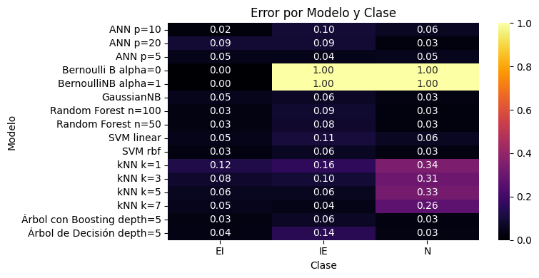

### Overall comment on model selection

In this project, where the goal is to predict splicing sites (classes EI and IE), it is crucial to choose models that not only achieve good overall f1-scores but are also precise for these classes without confusing non-splicing regions (class N).

The best-performing models for this task are SVM RBF, Random Forest (n>50), and Boosted Tree, as they offer the best balance between EI/IE classes without sacrificing specificity for class N.

ANN models also perform very well, with high and balanced f1-scores. However, GaussianNB offers nearly the same performance with lower computational cost.

Finally, kNN models, although they improve with higher k values, have lower f1-scores than the other models. The BernoulliNB model was completely discarded as it could not capture the data complexity.